# Report European Value Survey (EVS) for Statisticians

Stefan Zimmermann

16 6 2020

# Introduction

This project uses data from the [European Value Study (EVS)](https://search.gesis.org/research_data/ZA7500) and aims to examine attitudes towards gender roles and immigration for European countries. In the project report two variables on gender role and migration are descriptively examined and a first OLS regression is created. The project report will not only provide first results for Europe, but also additional individual reports for each country of the EVS, which will help to identify possible differences within the EU.

```r
# load packages
library(tidyverse)
library(foreign)
library(summarytools)
library(webshot)
library(htmltools)
library(caTools)
library(texreg)
library(purrr)
```

```r
# set data path
datapath <- "C:\\clone\\Modern Workflows\\assignment_2\\input\\raw"
outDir   <- "C:\\clone\\Modern Workflows\\assignment_2\\input\\unzip"
output <- "C:\\clone\\Modern Workflows\\assignment_2\\output\\"
outputpath <- "C:\\clone\\Modern Workflows\\assignment_2\\output\\country_reports\\"
scripts <- "C:\\clone\\Modern Workflows\\assignment_2\\scripts\\"
```

# Data Preparation

During data preparation, the required [EVS datasets (ZA7500)](https://search.gesis.org/research_data/ZA7500) are unzipped, downloaded and prepared for regression and descriptive analysis. Furthermore, the data set is reduced to the research-relevant variables.

```r
files <- list.files(datapath)
for (i in files) {
  print(i)
  unzip(zipfile = paste(datapath, i , sep = "\\"), exdir = outDir)
}

get_EVS_data <- function(datapath, variables, factor) {

  # Function get_EVS_data
  # Args:
  # datapath = datapath to dataframe in .sav format as string
  # variables = research variables as vector
  # factor = TRUE/FALSE to define class of selected variables

  # Returns:
  # dataset = dataframe

  data <- read.spss(datapath, use.value.label=factor, to.data.frame=TRUE)
  subset(data,select=variables)
}

data <- suppressWarnings(get_EVS_data(datapath = paste0(outDir, "\\", "ZA7500_v3-0-0.sav"),
                                      variables = c("id_cocas", "year", "age", "age_r", "age_r2",
                                                    "age_r3", "country", "v72", "v80", "v225", "v243_ISCED_1",
                                                    "v243_EISCED", "v243_r"), factor = TRUE))

data2 <- suppressWarnings(get_EVS_data(datapath = paste0(outDir, "\\", "ZA7500_v3-0-0.sav"),
                                       variables = c("id_cocas", "year", "age", "age_r", "age_r2",
                                                     "age_r3", "country", "v72", "v80", "v225", "v243_ISCED_1",
                                                     "v243_EISCED", "v243_r"), factor = FALSE))

data$age <- data2$age
data$age_square <- (data$age)^2
levels(data$v243_EISCED)[levels(data$v243_EISCED)=="other"] <- NA
levels(data$v243_r)[levels(data$v243_r)=="other"] <- NA
```

# Summary Statistics

The summary statistics of the analysis-ready data set include not only the variables of interest (v72 = When a mother works for pay, the children suffer; v80 = When jobs are scarce, employers should give priority to people of country over immigrants), but also a large number of demographic variables that are decisive for the analysis. Gender, age and educational level according to ISCED codes are used as demographic parameters. The first analysis of the whole data set shows that the survey year 2019 contains considerably less information than 2018 or 2017, the proportion of older respondents is higher and the group of young adults 15-29 is smaller. It is also particularly striking that the age limit was set at 82. This means that people who are significantly older are also considered to be 82 in the actually metric age variable, even if in reality they are much older. These special circumstances in the data must be taken into account in all results.

```r
get_summary <- function(dataset, output.path, source){

  # Function get_summary
  #
  # Args:
  # dataset = dataset
  # output.path = savepath for html output
  #
  # Returns:
  # html with summary statistics

  print(dfSummary(dataset, graph.magnif = 0.5, headings = FALSE),
        file = paste0(output.path , "summary_", deparse(substitute(dataset)), ".html"),
        footnote = paste0("<b>Descriptive statistics</b> of ", source))
}


get_summary(dataset = data,
            output.path = output,
            source = "EVS Data: doi:10.4232/1.13511")
```

| **No** | **Variable** | **Stats / Values** | **Freqs (% of Valid)** | **Graph** | **Valid** | **Missing** |
| --- | --- | --- | --- | --- | --- | --- |
| 1 | id_cocas [numeric] | Mean (sd) : 2017392064196.5 (257161889.7) min < med < max: 2017008000001 < 2017348001034.5 < 2017826001788 IQR (CV) : 439999370.5 (0) | 55276 distinct values |  | 55276 (100%) | 0 (0%) |
| 2 | year [factor] | 1. 2017 2. 2018 3. 2019 | 26876 ( 48.6% ) 24556 ( 44.4% ) 3844 ( 7.0% ) |  | 55276 (100%) | 0 (0%) |
| 3 | age [numeric] | Mean (sd) : 49.5 (17.7) min < med < max: 18 < 50 < 82 IQR (CV) : 29 (0.4) | 65 distinct values |  | 54954 (99.42%) | 322 (0.58%) |
| 4 | age_r [factor] | 1. 15-24 years 2. 25-34 years 3. 35-44 years 4. 45-54 years 5. 55-64 years 6. 65 and more years | 5170 ( 9.4% ) 8267 ( 15.0% ) 9078 ( 16.5% ) 9504 ( 17.3% ) 9778 ( 17.8% ) 13157 ( 23.9% ) |  | 54954 (99.42%) | 322 (0.58%) |
| 5 | age_r2 [factor] | 1. 15-29 years 2. 30-49 years 3. 50 and more years | 9274 ( 16.9% ) 17918 ( 32.6% ) 27762 ( 50.5% ) |  | 54954 (99.42%) | 322 (0.58%) |
| 6 | age_r3 [factor] | 1. 18-24 years 2. 25-34 years 3. 35-44 years 4. 45-54 years 5. 55-64 years 6. 65-74 years 7. 75 and more years | 5170 ( 9.4% ) 8267 ( 15.0% ) 9078 ( 16.5% ) 9504 ( 17.3% ) 9778 ( 17.8% ) 8320 ( 15.1% ) 4837 ( 8.8% ) |  | 54954 (99.42%) | 322 (0.58%) |
| 7 | country [factor] | 1. Albania 2. Azerbaijan 3. Austria 4. Armenia 5. Bosnia and Herzegovina 6. Bulgaria 7. Belarus 8. Croatia 9. Czechia 10. Denmark [ 24 others ] | 1435 ( 2.6% ) 1800 ( 3.3% ) 1644 ( 3.0% ) 1500 ( 2.7% ) 1724 ( 3.1% ) 1558 ( 2.8% ) 1548 ( 2.8% ) 1487 ( 2.7% ) 1811 ( 3.3% ) 3362 ( 6.1% ) 37407 ( 67.7% ) |  | 55276 (100%) | 0 (0%) |
| 8 | v72 [factor] | 1. agree strongly 2. agree 3. disagree 4. disagree strongly | 5278 ( 9.8% ) 15124 ( 28.0% ) 23167 ( 42.9% ) 10482 ( 19.4% ) |  | 54051 (97.78%) | 1225 (2.22%) |
| 9 | v80 [factor] | 1. agree strongly 2. agree 3. neither agree nor disagre 4. disagree 5. disagree strongly | 18818 ( 34.5% ) 15282 ( 28.0% ) 8417 ( 15.4% ) 7817 ( 14.3% ) 4231 ( 7.8% ) |  | 54565 (98.71%) | 711 (1.29%) |
| 10 | v225 [factor] | 1. male 2. female | 24726 ( 44.8% ) 30524 ( 55.2% ) |  | 55250 (99.95%) | 26 (0.05%) |
| 11 | v243_ISCED_1 [factor] | 1. Less than primary 2. Primary 3. Lower secondary 4. Upper secondary 5. Post-secondary non tertia 6. Short-cycle tertiary · 7. Bachelor or equivalent 8. Master or equivalent 9. Doctoral or equivalent… | 458 ( 0.8% ) 2423 ( 4.4% ) 8140 ( 14.8% ) 22778 ( 41.5% ) 2556 ( 4.7% ) 4187 ( 7.6% ) 6156 ( 11.2% ) 7593 ( 13.8% ) 533 ( 1.0% ) 84 ( 0.1% ) |  | 54908 (99.33%) | 368 (0.67%) |
| 12 | v243_EISCED [factor] | 1. No formal or less than pr 2. I - Primary education 3. II - Lower secondary (inc 4. IIIb - Upper secondary wi 5. IIIa - Upper secondary wi 6. IV - Post-secondary/advan 7. V1 - Bachelor's level 8. V2… | 458 ( 0.8% ) 2423 ( 4.4% ) 8140 ( 14.8% ) 5314 ( 9.7% ) 19567 ( 35.7% ) 4640 ( 8.5% ) 6156 ( 11.2% ) 8126 ( 14.8% ) |  | 54824 (99.18%) | 452 (0.82%) |
| 13 | v243_r [factor] | 1. lower 2. medium 3. higher | 11021 ( 20.1% ) 25334 ( 46.2% ) 18469 ( 33.7% ) |  | 54824 (99.18%) | 452 (0.82%) |
| 14 | age_square [numeric] | Mean (sd) : 2766 (1781.9) min < med < max: 324 < 2500 < 6724 IQR (CV) : 2871 (0.6) | 65 distinct values |  | 54954 (99.42%) | 322 (0.58%) |

**Descriptive statistics** of EVS Data: doi:10.4232/1.13511

# Descriptive Statistics

Chart 1 shows for different age groups if the respondent agrees to the statement that an employment of a woman/mother influences the development of a child negatively. The older age groups (55-64 and 65>=) agree with the statement more often than the younger age group. So it seems that age has an influence small infuence. Chart/statement 2 shows that the attitude towards migrants with the statement: “When jobs are scarce, employers should give priority to people of our country over immigrants” is almost the same. But again, it seems that the older population (65>=) has the most negative attitude towards migration.

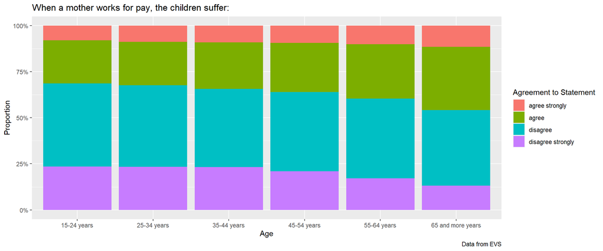

```r
data %>%
  filter(!is.na(age_r) & !is.na(v72)) %>%
  ggplot(aes(x = age_r, fill = v72)) +
  geom_bar(position = "fill") +
  labs(title="When a mother works for pay, the children suffer:", x = "Age", y = "Proportion", caption = "Data from EVS") +
  scale_y_continuous(labels = scales::percent) +
  scale_fill_discrete(name = "Agreement to Statement") +
  theme(legend.position = "right", legend.direction="vertical")
```

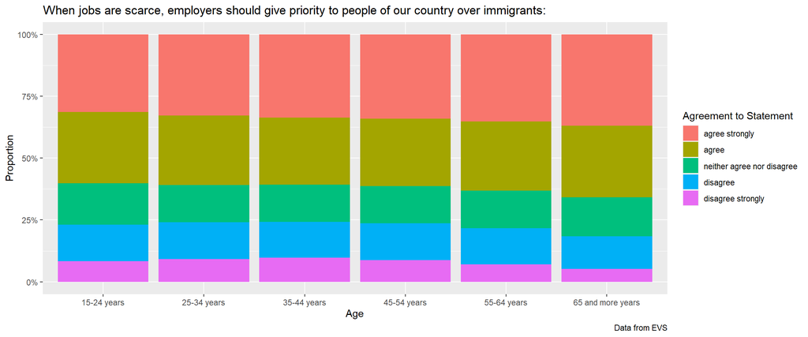

```r
data %>%
  filter(!is.na(age_r) & !is.na(v80)) %>%
  ggplot(aes(x = age_r, fill = v80)) +
  geom_bar(position = "fill") +
  labs(title="When jobs are scarce, employers should give priority to people of our country over immigrants:", x = "Age", y = "Proportion", caption = "Data from EVS") +
  scale_y_continuous(labels = scales::percent) +
  scale_fill_discrete(name = "Agreement to Statement") +
  theme(legend.position = "right", legend.direction="vertical")
```

```r
set.seed(100)
model1 <- lm(as.numeric(v72) ~ age + age_square + v225 + v243_r, data = data)
model2 <- lm(as.numeric(v80) ~ age + age_square + v225 + v243_r, data = data)
htmlreg(list(model1, model2),
file = paste0(output, "regression.html"),
single.row = TRUE,
stars = 0.05,
digits = 2,
custom.coef.names = c("Intercept", "Age", "Age Squared", "Sex: Female", "Medium Education Level", "High Education Level"),
caption = "OLS Regression on v72 (Model 1) and v80 (Model 2)",
caption.above = TRUE)
```

# OLS Regression on v72 (Model 1) and v80 (Model 2)

OLS Regression on v72 (Model 1) and v80 (Model 2)

|  | Model 1 | Model 2 |
| --- | --- | --- |
| Intercept | 2.66 (0.03)* | 2.29 (0.04)* |
| Age | -0.00 (0.00) | 0.00 (0.00) |
| Age Squared | -0.00 (0.00)* | -0.00 (0.00) |
| Sex: Female | 0.07 (0.01)* | -0.03 (0.01)* |
| Medium Education Level | 0.12 (0.01)* | -0.03 (0.01) |
| High Education Level | 0.41 (0.01)* | 0.46 (0.02)* |
| R<sup>2</sup> | 0.05 | 0.03 |
| Adj. R<sup>2</sup> | 0.05 | 0.03 |
| Num. obs. | 53375 | 53870 |

*p < 0.05